# HW 2

### Question 3

```r
library(MASS)
loc.mix <- function(n, p, mu1, mu2, Sigma) {

n1 <- rbinom(1, size = n, prob = p)
n2 <- n - n1
x1 <- mvrnorm(n1, mu = mu1, Sigma)
x2 <- mvrnorm(n2, mu = mu2, Sigma)
X <- rbind(x1, x2)
return(X[sample(1:n), ])
}
```

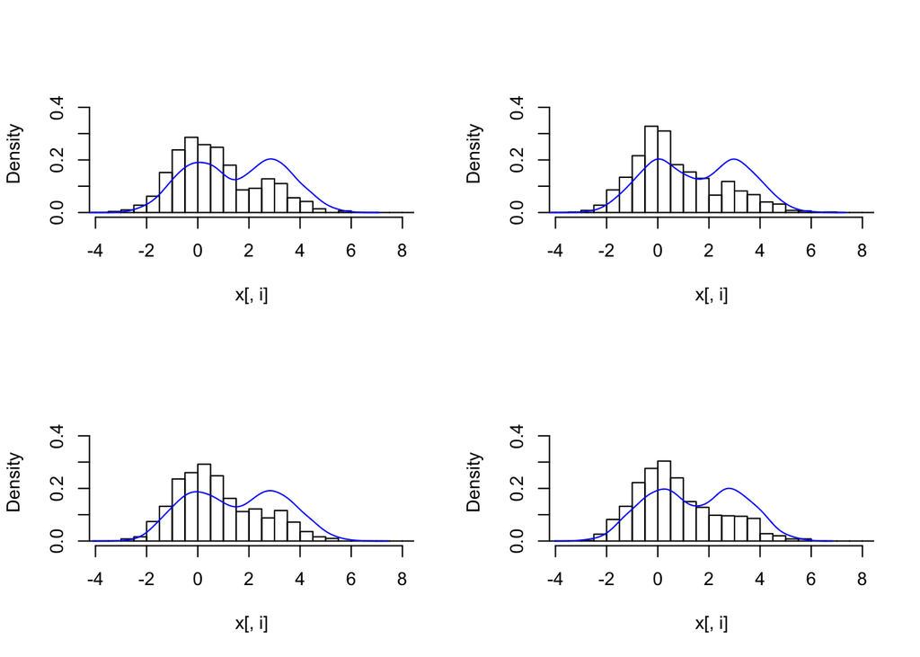

```r
#Generate 1000 values from two multivariate normal components:
x <- loc.mix(1000,
             p = .75, # p1 = .75
             mu1 = rep(0, 4), #First component from N(0,1)
             mu2 = rep(3, 4), #Second component from N(3,1)
             Sigma = diag(4))
r <- range(x) * 1.2
par(mfrow = c(2, 2))
for (i in 1:4){
    hist(x[ , i], xlim = r, ylim = c(0, .45), freq = FALSE,
         main = "", breaks = seq(-5, 10, .5))
  #superimpose multivariate normal with two components from N(0,1) and N(3,1)
    lines(density(mvrnorm(1000,mu=c(0,3),diag(2))), col = "blue")
}
```

Repeat with varying levels for p1:

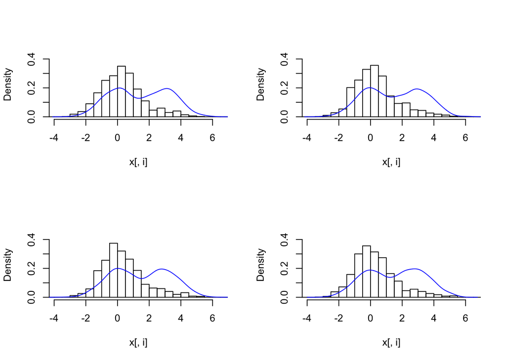

```r
### p1 = .9
x <- loc.mix(1000,
             p = .9,
             mu1 = rep(0, 4),
             mu2 = rep(3, 4),
             Sigma = diag(4))
r <- range(x) * 1.2
par(mfrow = c(2, 2))
for (i in 1:4){
    hist(x[ , i], xlim = r, ylim = c(0, .45), freq = FALSE,
         main = "", breaks = seq(-5, 10, .5))
  #superimpose multivariate normal with two components from N(0,1) and N(3,1)
    lines(density(mvrnorm(1000,mu=c(0,3),diag(2))), col = "blue")
}
```

p1 = .5

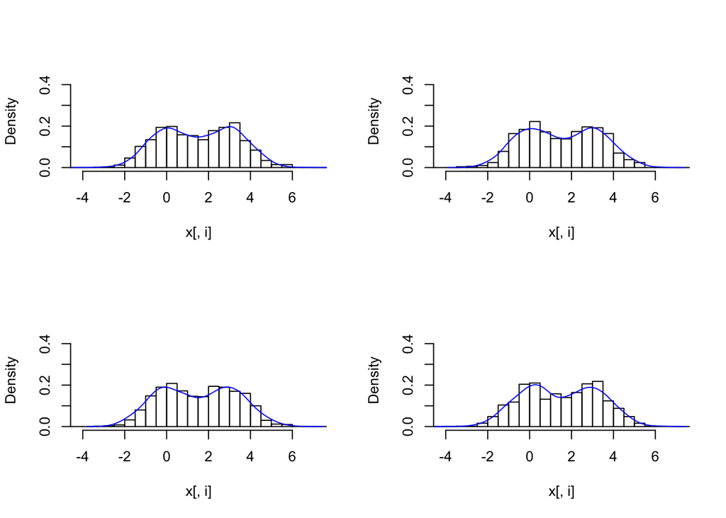

```r
# p1 = .5
x <- loc.mix(1000,
             p = .5,
             mu1 = rep(0, 4),
             mu2 = rep(3, 4),
             Sigma = diag(4))
r <- range(x) * 1.2
par(mfrow = c(2, 2))
for (i in 1:4){
    hist(x[ , i], xlim = r, ylim = c(0, .45), freq = FALSE,
         main = "", breaks = seq(-5, 10, .5))
  #superimpose multivariate normal with two components from N(0,1) and N(3,1)
    lines(density(mvrnorm(1000,mu=c(0,3),diag(2))), col = "blue")
}
```

To obtain a true bimodal distribution, the probability of sampling from each component must be .5. However, the following illustrations, with p1 = .45, .4, .35, and .3 respectively, show that the histogram will look fairly bimodal up until around .3, where it looks skewed with a large tail in the direction of the distribution with the smaller sampling probability.

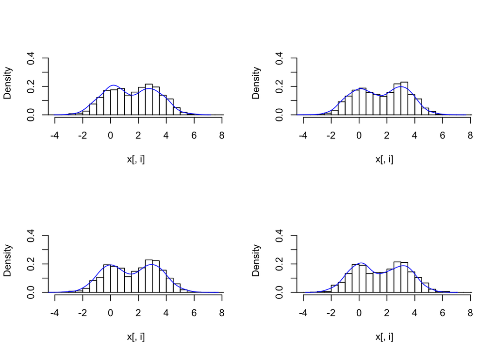

```r
# p1 = .45
x <- loc.mix(1000,
             p = .45,
             mu1 = rep(0, 4),
             mu2 = rep(3, 4),
             Sigma = diag(4))
r <- range(x) * 1.2
par(mfrow = c(2, 2))
for (i in 1:4){
    hist(x[ , i], xlim = r, ylim = c(0, .45), freq = FALSE,
         main = "", breaks = seq(-5, 10, .5))
  #superimpose multivariate normal with two components from N(0,1) and N(3,1)
    lines(density(mvrnorm(1000,mu=c(0,3),diag(2))), col = "blue")
}
```

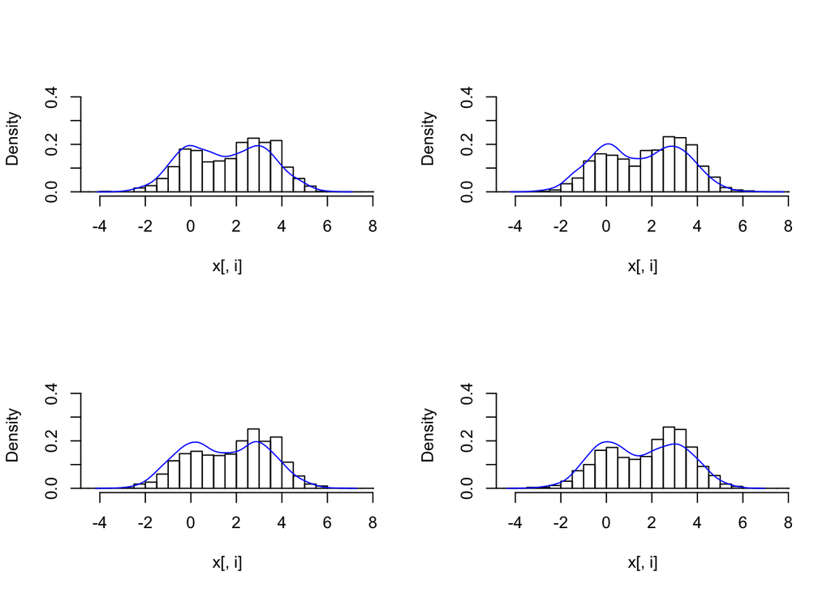

```r
# p1 = .4
x <- loc.mix(1000,
             p = .4,
             mu1 = rep(0, 4),
             mu2 = rep(3, 4),
             Sigma = diag(4))
r <- range(x) * 1.2
par(mfrow = c(2, 2))
for (i in 1:4){
    hist(x[ , i], xlim = r, ylim = c(0, .45), freq = FALSE,
         main = "", breaks = seq(-5, 10, .5))
  #superimpose multivariate normal with two components from N(0,1) and N(3,1)
    lines(density(mvrnorm(1000,mu=c(0,3),diag(2))), col = "blue")
}
```

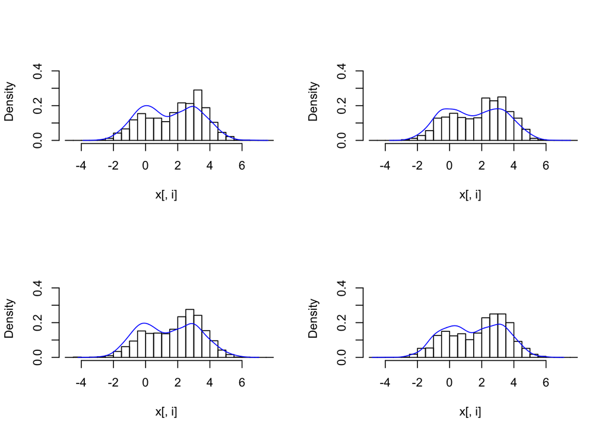

```r
# p1 = .35
x <- loc.mix(1000,
             p = .35,
             mu1 = rep(0, 4),
             mu2 = rep(3, 4),
             Sigma = diag(4))
r <- range(x) * 1.2
par(mfrow = c(2, 2))
for (i in 1:4){
    hist(x[ , i], xlim = r, ylim = c(0, .45), freq = FALSE,
         main = "", breaks = seq(-5, 10, .5))
  #superimpose multivariate normal with two components from N(0,1) and N(3,1)
    lines(density(mvrnorm(1000,mu=c(0,3),diag(2))), col = "blue")
}
```

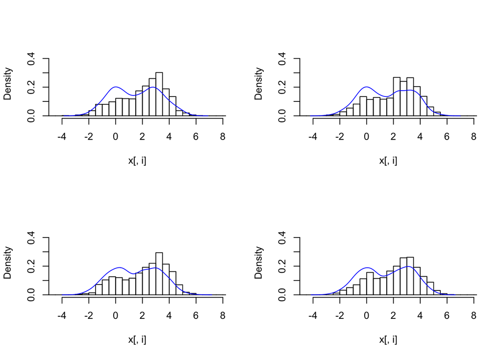

```r
# p1 = .3
x <- loc.mix(1000,
             p = .3,
             mu1 = rep(0, 4),
             mu2 = rep(3, 4),
             Sigma = diag(4))
r <- range(x) * 1.2
par(mfrow = c(2, 2))
for (i in 1:4){
    hist(x[ , i], xlim = r, ylim = c(0, .45), freq = FALSE,
         main = "", breaks = seq(-5, 10, .5))
  #superimpose multivariate normal with two components from N(0,1) and N(3,1)
    lines(density(mvrnorm(1000,mu=c(0,3),diag(2))), col = "blue")
}
```